# Group 6

# Bonus Problem Set

## 我們要做的是利用目前所學，分析在同一主題下的新聞中，各家媒體在報導中撰寫使用文字上的差異。在此我們針對三家規模較大的媒體，蘋果、中時與自由，各收集10則與“換柱”較相關的新聞來分析。

### 1. 文本前處理

```r
# set the working directory
setwd("D:/Kile/語言分析與資料科學/week6/Bonus/news")
# load the required packages
library(jiebaR)
```

```r
require(wordcloud)
# create the lists for placing the words frequency outcomes
news_list = list()
news_list_cut = list()
news_list_cut_table=list()
news_list_cut_dataframe=list()
# read lines to list
for(i in 1:length(list.files())){
    news_list[[i]]=readLines(list.files()[i],encoding="UTF-8")
}
# construct the word-cutting function
cutter=worker()
cutter$stop_word="C:/Program Files/R/R-3.2.2/library/jiebaRD/dict/stop_words.utf8"
# cut the words and put the outcomes into the new list
for(i in 1:length(news_list)){
    news_list_cut[[i]]=cutter[news_list[[i]]]
}
# put the cut words into tables
for(i in 1:length(news_list)){
    news_list_cut_table[[i]]=table(news_list_cut[[i]])
}
# transform the words-counts tables into data frames
for(i in 1:length(news_list)){
    news_list_cut_dataframe[[i]]=as.data.frame.table(news_list_cut_table[[i]],stringsAsFactors = FALSE)
}
# order the data frames by words' frequency in decreasing order
for(i in 1:length(news_list)){
    news_list_cut_dataframe[[i]]=news_list_cut_dataframe[[i]][order(news_list_cut_dataframe[[i]][2],decreasing=T),]
}
# rename the columns and rows
for(i in 1:length(news_list)){
    colnames(news_list_cut_dataframe[[i]])=c("word","count")
    rownames(news_list_cut_dataframe[[i]])=1:nrow(news_list_cut_dataframe[[i]])
}
# name the elements' names in the data frames list
for(i in 1:length(list.files())){
    names(news_list_cut_dataframe)[i]=substr(list.files()[i],1,nchar(list.files()[i])-4)
}
# remove the words with length equal to 1, which usually with little meaning
for(i in 1:length(list.files())){
    news_list_cut_dataframe[[i]]=news_list_cut_dataframe[[i]][nchar(news_list_cut_dataframe[[i]]$word)!=1,]
}
```

### 2. 以文字雲圖觀察各家媒體新聞用詞差異

#### 我們利用文字雲圖呈現各家媒體收集到的“換柱”新聞中，出現至少10次的詞。

#### 蘋果日報

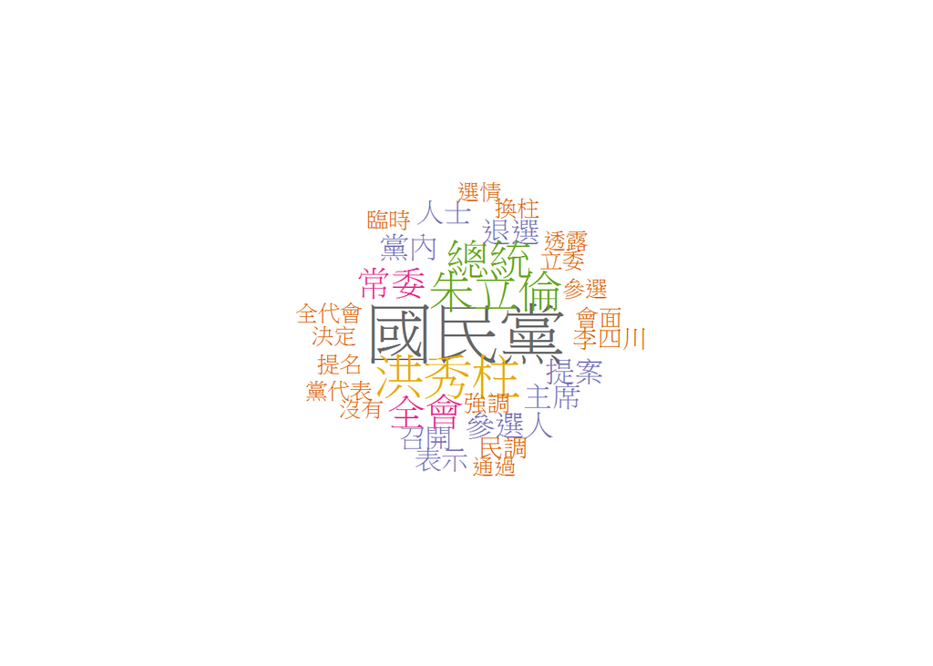

```r
# plot wordcloud graph
wordcloud(news_list_cut_dataframe[[1]]$word,news_list_cut_dataframe[[1]]$count, scale=c(3,0.5),min.freq=10, max.words=Inf, random.order=FALSE, rot.per=FALSE, use.r.layout=FALSE, colors=brewer.pal(8, "Dark2"),main=names(news_list_cut_dataframe)[1])
```

#### 中國時報

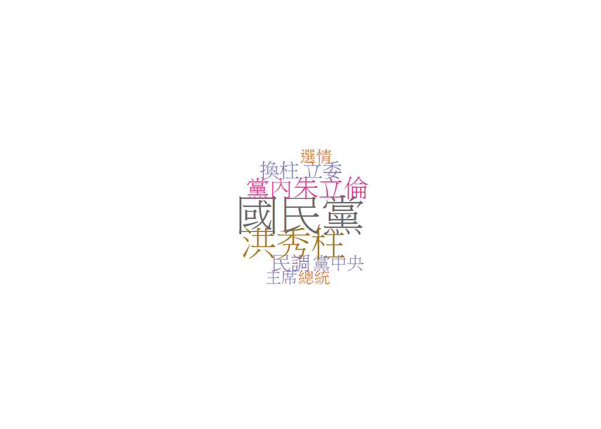

```r
wordcloud(news_list_cut_dataframe[[2]]$word,news_list_cut_dataframe[[2]]$count, scale=c(3,0.5),min.freq=10, max.words=Inf, random.order=FALSE, rot.per=FALSE, use.r.layout=FALSE, colors=brewer.pal(8, "Dark2"),main=names(news_list_cut_dataframe)[2])
```

#### 自由時報

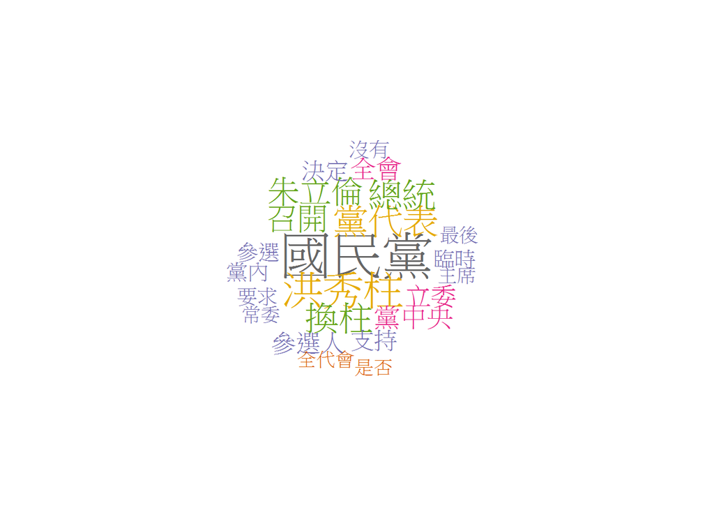

```r
wordcloud(news_list_cut_dataframe[[3]]$word,news_list_cut_dataframe[[3]]$count, scale=c(3,0.5),min.freq=10, max.words=Inf, random.order=FALSE, rot.per=FALSE, use.r.layout=FALSE, colors=brewer.pal(8, "Dark2"),main=names(news_list_cut_dataframe)[3])
```

結論:  
1. 從整體來看，中國時報在使用次數至少10次的詞中，顯得較不豐富。  
2. 雖然國民黨、洪秀柱、朱立倫以及總統四個詞明顯地都有在三家媒體中以高頻率出現，但是在彼此用詞的數量上也略有差異，根據文字的大小可以看出像是在蘋果日報裡“洪秀柱”和“朱立倫”兩詞出現的次數相當，而在其他兩家媒體裡則是有較大的差距。

### 3. 以橫向柱狀圖觀察各家媒體新聞用詞差異

#### 我們利用橫向柱狀圖呈現各家媒體“換柱”系列新聞中用詞數量前20名的字詞，並將三者間有重疊的詞以紅色長條標記出來。

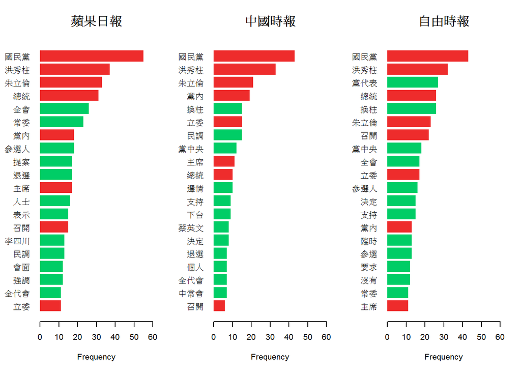

```r
for(i in 1:length(news_list)){
    news_list_cut_table[[i]]=news_list_cut_table[[i]][nchar(names(news_list_cut_table[[i]]))!=1]
    news_list_cut_table[[i]]=sort(news_list_cut_table[[i]],T)
}
par(mfrow=c(1,3))
for(i in 1:length(news_list)){
    name=c("蘋果日報","中國時報","自由時報")
    yrange=range(news_list_cut_table)
    barplot(sort(news_list_cut_table[[i]][1:20]),xlim = c(0,yrange[2]+5),horiz = TRUE,border=NA,las=1,col=ifelse(names(sort(news_list_cut_table[[i]][1:20]))%in%intersect(intersect(news_list_cut_dataframe[[1]][1:20,1],news_list_cut_dataframe[[2]][1:20,1]),news_list_cut_dataframe[[3]][1:20,1]),"firebrick2","springgreen3"),xlab="Frequency",main=name[i],cex.main=1.5)
}
```

結論:  
1. 在重疊用字的使用排名上，三家媒體各有其趨勢，比如說在“立委”一詞，於蘋果日報排在第20名，而在中國時報位居前段，自由時報落於中段。  
2. 雖然新聞為“換柱”的主題，但是蘋果日報裡“換柱”一詞未出現在其使用次數較高的詞語當中。  
3. 除了新聞裡牽涉到的主要角色“洪秀柱”與“朱立倫”，在蘋果日報裡“李四川”也出現在較高用詞頻率的排名裡，而在中國時報裡則是“蔡英文”，或許可以歸因於報導重點上的差異。